# H05 Stage 2: implementation, diagnostics, and V0 comparison

Nature Health analysis audit — author result gate

Published

August 1, 2026

## Result at the Stage 2 gate

The signed hypothesis is:

> H5: LEBA questionnaire factors correlate with selected personal light exposure metrics.

The approved primary analysis provides **no association that survives the complete 68-test Benjamini–Hochberg family**. All 68 fixed-site primary models are estimable. The archived diagnostic classification contains 19 acceptable and 49 acceptable-with-limitations cells. Following author review, the four sleep-environment cells are more conservatively designated **unfit for inference**, leaving 45 retained cells with specified limitations. The result does not support the submitted statement that exactly two H05 associations are significant.

The unfit classification is specific to the H05 sleep-environment response and model structure. It does not determine whether the underlying metric is suitable for another hypothesis that uses a different response variable or model structure.

The two numerically strongest F2 results remain positive before multiplicity adjustment:

- Time above 1,000 lx melEDI: ratio per participant SD of LEBA F2 = 1.234 (95% CI 1.084 to 1.405), raw Raw p = 0.002, BH-adjusted *p* = 0.124.
- Corrected melEDI dose: ratio per participant SD of LEBA F2 = 1.278 (95% CI 1.079 to 1.514), raw Raw p = 0.004, BH-adjusted *p* = 0.124.

These are observational estimates, not multiplicity-retained findings. The duration model is acceptable. The dose model is acceptable with an ordinary Gaussian residual warning. Both directions are stable in the registered random-site, leave-one-site-out, paired-placement, and gap-timing-unaware dataset.

## METRIC-010 bounded MDER amendment

The author-approved MDER estimand is now the arithmetic mean of viable one-minute MEDI/LIGHT ratios. A minute is viable only when both channels are finite and strictly positive. The channels are placed on a complete 1,440-minute local wall-clock grid; fall-back duplicate local minutes are averaged channel-wise before forming the ratio and spring-forward absent minutes remain missing. MDER is retained with at least 720 viable minute ratios. It is not weighted by a time profile and is not a ratio of daily integrals.

Only the 32 MDER model cells across the eight accepted H05 run scenarios were rebuilt. The three complete 68-test BH vectors were then recalculated from the unchanged 64 non-MDER raw p-values plus the four current MDER p-values in each inferential family. The other 16 metric frames, model objects, estimates, intervals, raw tests, diagnostics, and sensitivities remain byte- or value-identical as applicable. The 20-row reconciliation record verifies each preservation boundary.

|  | MDER difference per LEBA SD (95% CI) | Raw p | BH-adjusted p | Exact fitted sample |
| --- | --- | --- | --- | --- |
| Primary near eye |  |  |  |  |
| F2 | +0.004 (-0.011 to +0.019) | 0.586 | 0.747 | 137 participants; 702 participant-days; 9 sites |
| F3 | -0.004 (-0.019 to +0.011) | 0.593 | 0.747 | 137 participants; 702 participant-days; 9 sites |
| F4 | -0.010 (-0.026 to +0.005) | 0.162 | 0.380 | 137 participants; 702 participant-days; 9 sites |
| F5 | -0.020 (-0.035 to -0.004) | 0.010 | 0.169 | 137 participants; 702 participant-days; 9 sites |
| Complementary chest |  |  |  |  |
| F2 | -0.002 (-0.041 to +0.038) | 0.938 | 0.981 | 152 participants; 732 participant-days; 8 sites |
| F3 | -0.013 (-0.050 to +0.024) | 0.471 | 0.761 | 152 participants; 732 participant-days; 8 sites |
| F4 | -0.018 (-0.056 to +0.019) | 0.327 | 0.761 | 152 participants; 732 participant-days; 8 sites |
| F5 | -0.017 (-0.055 to +0.022) | 0.387 | 0.761 | 152 participants; 732 participant-days; 8 sites |

Each placement uses its separately declared complete 68-test BH family.

The primary near-eye MDER sample contains 702 participant-days from 137 participants at nine sites; the complementary chest sample contains 732 participant-days from 152 participants at eight sites. No MDER association is BH-retained. The current primary near-eye F5 interval excludes zero before multiplicity adjustment, but its Raw *p* = 0.010 and BH-adjusted *p* = 0.169 do not support a multiplicity-retained claim.

The accepted common-sample comparison contains 489 matched participant-days from 107 participants at eight sites for MDER; all four near-eye and chest directions agree and component 95% confidence intervals overlap. The gap-timing-unaware all-available MDER samples contain 687 near-eye participant-days from 137 participants and 723 chest participant-days from 152 participants. Its exact paired/common comparison contains 478 days from 107 participants at eight sites. Its near-eye 68-test family retains zero MDER associations; all four near-eye directions agree with the primary analysis, and all four paired near-eye and chest directions agree with overlapping component confidence intervals.

Current-estimand MDER upper-tail screen

Tukey Q3 + 3 × IQR identifies candidate influence cases; it is not an exclusion rule

| Placement | Observations | Participants | Median | Outer fence | Maximum | Days above outer fence |
| --- | --- | --- | --- | --- | --- | --- |
| Chest | 732 | 152 | 0.749 | 1.283 | 3.574 | 3 |
| Near eye | 702 | 137 | 0.724 | 1.247 | 1.857 | 1 |

One near-eye day and three chest days exceed the current-estimand outer fence. The maximum is 1.857 near eye and 3.574 at the chest. Candidate day- and participant-deletion refits changed the four near-eye coefficients by at most 0.234 full-model standard errors, without sign reversal. At the chest, the maximum changes for F2 and F4 were 0.823 and 0.828 standard errors; the very small F2 coefficient reversed direction in one deletion. All 44 influence refits passed. All chest sensitivity intervals contain zero; the four near-eye F5 deletion intervals remain below zero, as does its unadjusted primary interval. The complementary chest MDER coefficients are therefore upper-tail-sensitive, while the F5 near-eye direction is stable to these deletions. Neither pattern is multiplicity-retained, so the family-wide conclusion does not change.

The repaired gap-timing-unaware all-available MDER branch underwent the same bounded upper-tail and deletion-influence assessment. All 44 refits passed; 40 sensitivity intervals contained zero. The four near-eye coefficients changed by at most 0.233 full-model standard errors without reversing direction. At the chest, the maximum changes were 0.823 standard errors for F2 and 0.841 for F4; the very small F2 coefficient reversed direction in two deletions, and every chest interval contained zero. These diagnostics qualify the complementary chest magnitudes but do not alter the zero-retained H05-F3 conclusion.

METRIC-010 preservation reconciliation

Non-MDER raw scientific content remains frozen; only complete-family BH-derived fields may change

| Artifact | Invariant scope | Non-MDER rows or objects | Verified |
| --- | --- | --- | --- |
| frames | all non-MDER fields except declared complete-family BH derivatives | 512 | TRUE |
| effects | all non-MDER fields except declared complete-family BH derivatives | 512 | TRUE |
| tests | all non-MDER fields except declared complete-family BH derivatives | 512 | TRUE |
| master | all non-MDER fields except declared complete-family BH derivatives | 512 | TRUE |
| diagnostics | all non-MDER fields except declared complete-family BH derivatives | 512 | TRUE |
| model_manifest | all non-MDER fields except declared complete-family BH derivatives | 1,536 | TRUE |
| influence | all non-MDER fields except declared complete-family BH derivatives | 1,536 | TRUE |
| random_site | all non-MDER fields except declared complete-family BH derivatives | 128 | TRUE |
| loo | all non-MDER fields except declared complete-family BH derivatives | 576 | TRUE |
| loo_summary | all non-MDER fields except declared complete-family BH derivatives | 64 | TRUE |
| spearman | all non-MDER fields except declared complete-family BH derivatives | 512 | TRUE |
| site_spearman | all non-MDER fields except declared complete-family BH derivatives | 1,088 | TRUE |
| loo_spearman | all non-MDER fields except declared complete-family BH derivatives | 1,088 | TRUE |
| paired | all non-MDER fields except declared complete-family BH derivatives | 64 | TRUE |
| gap | all non-MDER fields except declared complete-family BH derivatives | 64 | TRUE |
| v0 | all non-MDER fields except declared complete-family BH derivatives | 128 | TRUE |
| v0_to_new | all non-MDER fields except declared complete-family BH derivatives | 64 | TRUE |
| diagnostic_plot | all non-MDER fields except declared complete-family BH derivatives | 88,648 | TRUE |
| model_frame_objects | all 128 non-MDER model-frame objects | 128 | TRUE |
| inferential_model_objects | all 192 non-MDER inferential model bundles | 192 | TRUE |

Repaired gap-timing-unaware MDER reseal

Only four gap MDER frames and four H05-F3 MDER bundles were replaced; 27 non-MDER adjusted p-values and 26 ranks changed as BH derivatives

| Check | Scope | Allowed change | Changed rows | Verified |
| --- | --- | --- | --- | --- |
| frozen_non_target_frames | all rows outside repaired gap MDER | none | 0 | TRUE |
| frozen_non_target_effects | all rows outside repaired gap MDER | none | 0 | TRUE |
| frozen_non_target_diagnostics | all rows outside repaired gap MDER | none | 0 | TRUE |
| frozen_non_target_model_manifest | all rows outside repaired gap MDER | none | 0 | TRUE |
| frozen_non_target_influence | all rows outside repaired gap MDER | none | 0 | TRUE |
| frozen_non_target_spearman | all rows outside repaired gap MDER | none | 0 | TRUE |
| frozen_non_target_gap | all rows outside repaired gap MDER | none | 0 | TRUE |
| immutable_model_frame_objects | 132 stored frames excluding four repaired gap MDER frames | none | 0 | TRUE |
| immutable_inferential_model_objects | 200 fitted bundles excluding four repaired gap MDER bundles | none | 0 | TRUE |
| H05_F1_F2_complete_tests | complete primary and complementary 68-test families | none | 0 | TRUE |
| H05_F3_non_MDER_raw_tests | 64 non-MDER raw tests in repaired gap family | none | 0 | TRUE |
| H05_F3_non_MDER_BH_derivatives | mathematically derived H05-F3 BH fields only | p_adjusted;family_rank | 27 | TRUE |
| primary_MDER_upper_tail | four primary MDER upper-tail runs and summaries | none | 0 | TRUE |
| primary_MDER_influence_file | artifacts/08_diagnostics/H05/H05_mder_metric010_influence_refits.csv | none | 0 | TRUE |
| primary_paired_comparison_file | artifacts/09_tables/H05/H05_paired_placement_comparison.csv | none | 0 | TRUE |
| primary_paired_source_file | artifacts/11_source_data/H05/H05_paired_effect_comparison_data.csv | none | 0 | TRUE |

The former profile-support and preselected anomalous-device-day batteries were defined for a different MDER estimand and were not imported into this amendment. The current-estimand upper-tail and influence checks above replace those non-transferable obligations. No full 17-metric rerun, bootstrap, or simulation was performed.

## METRIC-011 bounded L10-mean amendment

The approved numerical-zero rule is applied before modelling to offset geometric means such as darkest-10-hour mean melEDI. A back-transformed value within the unit-aware floating-point tolerance is set to exact zero only when every finite source minute in that window is exactly zero. Missing minutes remain missing and are never imputed as zero. For the affected L10 windows the tolerance is (2.220446049250313^{-14}) lx.

The shared rebuild changed eight primary L10-mean cells from (4.163336342344337^{-17}) lx to exact zero: three near-eye and five chest participant-days. Because every changed day belongs to both its all-available and paired/common sample, four primary L10 frames and 16 factor-model cells were rebuilt. The registered random-site sensitivities and near-eye leave-one-site-out analyses for those cells were also refit. Fitted sample sizes did not change. The gap-timing-unaware L10 frames already contained exact zeros and were repinned without a model refit.

L10-mean results after numerical-zero normalization.

|  | Ratio per LEBA SD (95% CI) | Raw p | BH-adjusted p | Exact fitted sample |
| --- | --- | --- | --- | --- |
| Primary near eye |  |  |  |  |
| F2 | 0.995 × (0.905 to 1.094) | 0.917 | 0.958 | 141 participants; 816 participant-days; 9 sites |
| F3 | 0.956 × (0.871 to 1.049) | 0.322 | 0.577 | 141 participants; 816 participant-days; 9 sites |
| F4 | 0.921 × (0.838 to 1.013) | 0.080 | 0.351 | 141 participants; 816 participant-days; 9 sites |
| F5 | 0.970 × (0.879 to 1.070) | 0.526 | 0.716 | 141 participants; 816 participant-days; 9 sites |
| Complementary chest |  |  |  |  |
| F2 | 0.967 × (0.884 to 1.056) | 0.441 | 0.761 | 154 participants; 902 participant-days; 8 sites |
| F3 | 0.965 × (0.886 to 1.050) | 0.395 | 0.761 | 154 participants; 902 participant-days; 8 sites |
| F4 | 0.965 × (0.886 to 1.051) | 0.402 | 0.761 | 154 participants; 902 participant-days; 8 sites |
| F5 | 0.988 × (0.904 to 1.079) | 0.781 | 0.907 | 154 participants; 902 participant-days; 8 sites |

Each placement uses its separately declared complete 68-test BH family.

Across the 16 rebuilt primary L10 cells, the largest absolute coefficient change was 3.61e-12 on the model scale per LEBA point. Seven of the eight inferential raw p-values changed at full precision; two primary-family adjusted p-values changed below the required three-decimal display precision, and no family rank changed. The near-eye L10 diagnostics remain acceptable with specified Gaussian limitations; the chest and paired/common L10 diagnostics retain their stronger Gaussian-misfit warnings. No L10 association is BH-retained, and all three complete 68-test families still retain zero associations.

METRIC-011 frozen-result reconciliation.

METRIC-011 preservation reconciliation

All non-L10 fits and all gap-timing-unaware L10 fits remain frozen; only complete-family BH-derived fields may update

| Artifact | Invariant scope | Frozen rows or objects | Verified |
| --- | --- | --- | --- |
| frames | all rows outside primary L10, excluding declared BH-derived fields | 528 | TRUE |
| effects | all rows outside primary L10, excluding declared BH-derived fields | 528 | TRUE |
| tests | all rows outside primary L10, excluding declared BH-derived fields | 528 | TRUE |
| master | all rows outside primary L10, excluding declared BH-derived fields | 528 | TRUE |
| diagnostics | all rows outside primary L10, excluding declared BH-derived fields | 528 | TRUE |
| model_manifest | all rows outside primary L10, excluding declared BH-derived fields | 1,584 | TRUE |
| influence | all rows outside primary L10, excluding declared BH-derived fields | 1,584 | TRUE |
| random_site | all rows outside primary L10, excluding declared BH-derived fields | 128 | TRUE |
| loo | all rows outside primary L10, excluding declared BH-derived fields | 576 | TRUE |
| loo_summary | all rows outside primary L10, excluding declared BH-derived fields | 64 | TRUE |
| spearman | all rows outside primary L10, excluding declared BH-derived fields | 528 | TRUE |
| site_spearman | all rows outside primary L10, excluding declared BH-derived fields | 1,088 | TRUE |
| loo_spearman | all rows outside primary L10, excluding declared BH-derived fields | 1,088 | TRUE |
| paired | all rows outside primary L10, excluding declared BH-derived fields | 64 | TRUE |
| gap | all rows outside primary L10, excluding declared BH-derived fields | 64 | TRUE |
| v0 | all rows outside primary L10, excluding declared BH-derived fields | 128 | TRUE |
| v0_to_new | all rows outside primary L10, excluding declared BH-derived fields | 64 | TRUE |
| diagnostic_plot | all rows outside primary L10, excluding declared BH-derived fields | 87,736 | TRUE |
| model_frame_objects | all 132 stored frames outside the four primary L10 frames | 132 | TRUE |
| inferential_model_objects | all 196 fitted bundles outside the eight primary L10 bundles | 196 | TRUE |
| gap_l10_frame_objects | all four gap-timing-unaware L10 frames | 4 | TRUE |
| gap_l10_inferential_model_objects | all four gap-timing-unaware L10 inferential bundles | 4 | TRUE |

The 22 reconciliation checks cover every result table plus the stored model frames and inferential bundles. They confirm that all 16 non-L10 fits and all accepted MDER outputs remain frozen apart from any mathematically dependent BH display fields. No full 17-metric rerun, bootstrap, simulation, or other resampling was performed.

## Author decisions implemented

Stage 1 decisions implemented in Stage 2

The author approved all 13 items on 2026-08-01

| Decision | Gate | Disposition | Approved |
| --- | --- | --- | --- |
| 1 | H05-G1-primary-estimand | Approved Option A: site-adjusted metric model is primary | TRUE |
| 2 | H05-factor-manifest | Approved LEBA F2-F5 manifest and Factor 1 exclusion | TRUE |
| 3 | H05-metric-manifest | Approved exact 17-member repaired metric manifest | TRUE |
| 4 | H05-analysis-unit-hierarchy | Approved participant-day hierarchy and participant-level IS/IV models | TRUE |
| 5 | H05-response-package | Approved current H01 response-family and transformation package | TRUE |
| 6 | H05-leba-scaling | Approved participant-mean-centered raw scores; effects per point and participant SD; no within-site standardization | TRUE |
| 7 | H05-site-handling | Fixed site approved as primary because H01 showed more stable fixed-site fits; registered random site retained as sensitivity | TRUE |
| 8 | H05-multiplicity | Approved complete 68-member BH families and no secondary significance screen for descriptive sensitivities | TRUE |
| 9 | H05-clock-rules | Approved continuous ranges and strict-after-16 L10 conversion; H01 already resolved the issue; no noon sensitivity | TRUE |
| 10 | H05-placement-sample | Near-eye all-available primary; all-available chest complementary; paired/common near-eye and chest plus other placements as sensitivities | TRUE |
| 11 | H05-intervals | Approved declared Wald model intervals and descriptive Spearman intervals | TRUE |
| 12 | H05-diagnostics-sensitivities | Approved diagnostic, sensitivity, adequacy, and failure rules | TRUE |
| 13 | H05-claim-gate | Approved withdrawal of V0 claims until Stage 2 verification | TRUE |

### Fixed site is primary

The author’s conditional decision 7 resolves to fixed site as primary. In the H01 main near-eye all-available evidence, every fixed-site model converged with a positive-definite Hessian and none was singular. The corresponding random-site descriptions included non-estimable and singular fits. H05 therefore uses submitted-order, sum-to-zero fixed-site contrasts for primary inference and preserves the registered random-site formula as a named sensitivity.

H01 evidence used to resolve H05 site handling

Audit evidence only; H05 outcomes are fitted independently

| Fixed metrics | Fixed converged | Fixed PD Hessian | Fixed singular | Random pass | Random unstable | Random non-estimable | Random singular |
| --- | --- | --- | --- | --- | --- | --- | --- |
| 17 | 17 | 17 | 0 | 13 | 2 | 2 | 2 |

### Clock and placement decisions

H05 uses the H01-approved continuous clock ranges and subtracts 24 hours from darkest-10-hour midpoints strictly later than 16:00. The author explicitly excluded a noon sensitivity because H01 had already resolved the issue. Main near-eye all-available data are primary. All-available chest data form a separate complementary 68-test family. Exact paired/common near-eye and chest analyses are sensitivities. They are fitted separately; placements are never treated as independent observations in one pooled model.

## Reproducible implementation

### Frozen inputs

Frozen inputs and inherited analytical sources

Every observed hash equals the approved hash

| Role | Path | SHA-256 | Verified |
| --- | --- | --- | --- |
| main | artifacts/06_model_data/H01.rds | 0328fe1a698bc13965feb0b68b03ccf0fd20f32b55d6148635811b0d674e0a00 | TRUE |
| main_manifest | artifacts/12_manifests/H01_model_data_artifacts.csv | 25978c5d6903e6e835c1aff6a9bc2e7552b85295e8d840d3dd65bbf9b1eb6b72 | TRUE |
| manuscript_prepared_data | artifacts/06_model_data/H01/scenarios/manuscript_prepared_data/H01.rds | 3c70363fc0468202a431904aa9d9444f2858af2e3add3475a56c872b49a18bd6 | TRUE |
| manuscript_prepared_data_manifest | artifacts/12_manifests/H01_manuscript_prepared_data_artifacts.csv | e0d98178ede61b74353e3a654e7f1b53d7e1c915833a2cda74eea45ed02f383b | TRUE |
| leba | artifacts/06_model_data/normalized_inputs/leba.rds | 71882566d4665dde757a13b18e56c1f7308e855ea22bced4384e91254e64e636 | TRUE |
| v0_near_eye | data/H1_results.RData | d274865818cc4a0364dae9a444b9be44be02424daa8ad74b9452840f3115b3dc | TRUE |
| v0_chest | data/H1_results_chest.RData | 01f91db675d1aa6ae96b6aa7bbc45b2f86445e851a37020d1fe5335d802de9b5 | TRUE |
| h01_contract_source | scripts/hypotheses/H01/h01_contract.R | 9151f2ca8ef549d16df1465768ed5b33c0aa33b37dc315a13e06d795ba20de2e | TRUE |
| h01_modeling_source | scripts/hypotheses/H01/h01_modeling.R | a8879209e0d7c42f2e0de0d459e3cfbf7218cec27afd8f39a50c846ed43f9388 | TRUE |
| h01_fit_results_site_evidence | artifacts/07_models/H01/H01_fit_results.rds | 16b5ab67234c73d7cd7e14f29bf4b96bda9caff1bb2e786e3027aa59825d32c7 | TRUE |
| metric010_decision | audit/decisions/mder_mean_of_viable_ratios.md | 1664347de976057807fcb5ac6e24bd4b66af1fe32378fabd1f2acafcfc9266de | TRUE |
| primary_metric_manifest | artifacts/12_manifests/metric_artifacts.csv | 028bce108339c1277df4a070597430ea20b49c34c2888f4eef42741c1fe76a5e | TRUE |
| independent_mder_audit_manifest | artifacts/08_diagnostics/mder_METRIC-010/audit_manifest.csv | 5bd34fd4ac26dc2761540393d40e096cde835d8dd4b4edda9253243c9083d4bb | TRUE |
| base_model_manifest | artifacts/12_manifests/base_model_data_artifacts.csv | 8344bdc0339a53079bf9eeb7d86de1ad7c15373641c3a0a5a01d040b418895ce | TRUE |
| gap_preparation_manifest | artifacts/12_manifests/manuscript_prepared_data_artifacts.csv | 4ed62fbe58de65a6d05d8cfc6b5d870d7c74a3c83fe89bcd72bd1dd838698935 | TRUE |
| gap_repair_evidence_manifest | audit/reconciliation/mder_METRIC-010_gap_repair/gap_repair_evidence_manifest.csv | 81e3aa9439b88cf239d6669dc4343cfb146cd2f45790bae412ab837156315018 | TRUE |
| metric011_decision | audit/decisions/l10_numerical_zero_normalization.md | 23b9f70d1d16f7fd3ebbdbc57aaf78c0a701fe1f9d22bd667d926cd320d40797 | TRUE |
| metric011_evidence_manifest | audit/reconciliation/l10_METRIC-011/METRIC-011_evidence_manifest.csv | a37efd3449a8d1a6065d0eb8964bd6cf8b241f1683a26c065ea1a946e23214fb | TRUE |
| site_context_manifest | artifacts/12_manifests/site_solar_context_artifacts.csv | c0c6d7f97782c0d880a213050f576213f5d56b3204a02732f6399e7e4aeb8518 | TRUE |
| primary_near_eye_context | artifacts/06_model_data/base/metrics_glasses_participant_day_context.rds | 013afe75e9b75b141b4cb48d04111a9e6c688630085a24c9fe07ca3d142a4e9a | TRUE |
| primary_chest_context | artifacts/06_model_data/base/metrics_chest_participant_day_context.rds | 497466ccd1a35635cca40bb8f9ce51efb97321ab04b42ee1bb76785e466a2057 | TRUE |

All scientific calculations were run in R 4.6.1 from a clean `Rscript --vanilla` session with the project R 4.6 library. The H05 driver verified the two model-data artifacts, both model-data manifests, normalized LEBA input, V0 workspaces, inherited H01 response/model functions, and the H01 fit result used only for the site-structure decision. The complete execution command was:

```
R_LIBS=renv/library/macos/R-4.6/aarch64-apple-darwin23 \
NATHEALTH_PROJECT_ROOT=<project-root> \
H05_STAGE=fit H05_RUN_LOO=true \
Rscript --vanilla scripts/hypotheses/H05/run_h05_stage2.R
```

The later METRIC-010 amendment used the bounded H05 updater below. It refits only MDER and stops if any non-MDER scientific field or stored object changes.

```
R_LIBS=renv/library/macos/R-4.6/aarch64-apple-darwin23 \
NATHEALTH_PROJECT_ROOT=<project-root> \
Rscript --vanilla scripts/hypotheses/H05/refresh_h05_mder_metric010.R
```

After the shared gap-timing-unaware reconstruction was repaired, the following bounded reseal refit only its four MDER runs (16 factor-model cells), rebuilt the exact matched comparison, and recomputed only the H05-F3 BH-derived fields.

```
NATHEALTH_PROJECT_ROOT=<project-root> \
Rscript --vanilla scripts/hypotheses/H05/reseal_h05_gap_mder_metric010.R
```

The METRIC-011 reseal then rebuilt only the four primary L10 frames, 16 core factor-model cells, eight registered random-site sensitivities, and 36 near-eye leave-one-site-out refits. It stopped unless every non-L10 fit and every gap-timing-unaware L10 fit retained its accepted identity.

```
NATHEALTH_PROJECT_ROOT=<project-root> \
Rscript --vanilla scripts/hypotheses/H05/reseal_h05_l10_metric011.R
```

### LEBA and model-frame contract

All 184 questionnaire records are unique by site and participant. All 20 ordered items and all four stored factor scores reproduce exactly; no item or factor value is missing. F2 reverses only item 04. F3–F5 are direct sums. Factor 1 remains excluded because it was not administered for the unfiltered study spectacles.

For every exact run–metric–factor frame, LEBA is centered using each unique participant once; repeated days do not weight the mean or SD. Effects are reported per raw point and per that frame’s participant SD. No within-site standardization is used. Every frame’s ordered row hash, centering mean, SD, participants, participant-days, observations, and sites are persisted.

### Models, tests, and intervals

For 15 participant-day metrics, the primary full model is

$$g(Y_{dij}) = \alpha + \mathrm{site}_j + \beta\,\mathrm{LEBA}_{ij,c}
+ b_{ij},$$

with a participant random intercept. IS and IV are participant-level and use the otherwise identical fixed-site linear model without a participant random intercept. The response family, transformation, link, and reader-scale effect follow the current approved H01 17-metric registry. Gaussian likelihood-ratio comparisons use ML and final Gaussian mixed models use REML. Tweedie models use a log link and ML.

Each inferential test compares the full model with a reduced model that removes only LEBA on an identical ordered frame. Effect intervals are two-sided 95% Wald intervals from the final model. The test (p)-value is the one-degree-of-freedom full-versus-reduced likelihood-ratio test. Descriptive Spearman coefficients use a model-compatible participant summary and an explicit approximate Fisher-(z) 95% interval; they have no (p)-values or significance screen.

Complete multiplicity families

No family was shortened after results were observed

| Family | Planned | Rows | Observed | BH-adjusted p <= 0.050 | R vector check |
| --- | --- | --- | --- | --- | --- |
| H05-F1-primary | 68 | 68 | 68 | 0 | TRUE |
| H05-F2-complementary-chest | 68 | 68 | 68 | 0 | TRUE |
| H05-F3-manuscript-prepared | 68 | 68 | 68 | 0 | TRUE |

## Exact primary samples

Primary near-eye model samples — metrics 1–9

| Metric | Unit | Observations | Participants | Participant-days | Represented days | Sites |
| --- | --- | --- | --- | --- | --- | --- |
| Interdaily stability | participant | 141 | 141 | NA | 816 | 9 |
| Intradaily variability | participant | 141 | 141 | NA | 816 | 9 |
| Mean melEDI | participant_day | 816 | 141 | 816 | 816 | 9 |
| Brightest 10 h mean | participant_day | 816 | 141 | 816 | 816 | 9 |
| Darkest 10 h mean | participant_day | 816 | 141 | 816 | 816 | 9 |
| Time above 1,000 lx melEDI | participant_day | 816 | 141 | 816 | 816 | 9 |
| Time above 250 lx melEDI during wake | participant_day | 737 | 141 | 737 | 737 | 9 |
| Time below 10 lx melEDI before sleep | participant_day | 655 | 139 | 655 | 655 | 9 |
| Time below 1 lx melEDI during sleep | participant_day | 778 | 141 | 778 | 778 | 9 |

Primary near-eye model samples — metrics 10–17

| Metric | Unit | Observations | Participants | Participant-days | Represented days | Sites |
| --- | --- | --- | --- | --- | --- | --- |
| Longest continuous period above 250 lx melEDI | participant_day | 816 | 141 | 816 | 816 | 9 |
| Midpoint of the brightest 10 hours | participant_day | 816 | 141 | 816 | 816 | 9 |
| Midpoint of the darkest 10 hours | participant_day | 816 | 141 | 816 | 816 | 9 |
| Mean timing of exposure above 250 lx melEDI | participant_day | 742 | 141 | 742 | 742 | 9 |
| First light timing above 250 lx melEDI | participant_day | 727 | 140 | 727 | 727 | 9 |
| Last light timing above 250 lx melEDI | participant_day | 687 | 141 | 687 | 687 | 9 |
| melEDI dose | participant_day | 761 | 141 | 761 | 761 | 9 |
| Melanopic daylight efficacy ratio | participant_day | 702 | 137 | 702 | 702 | 9 |

For paired IS/IV, H05 derives the exact common participant keys from the two all-available placement frames because the upstream H01 paired artifact conservatively omitted participant-level recomputation. Both placements use the same 112 participants and eight sites. Daily paired models retain the upstream exact common participant-date keys.

## Primary results

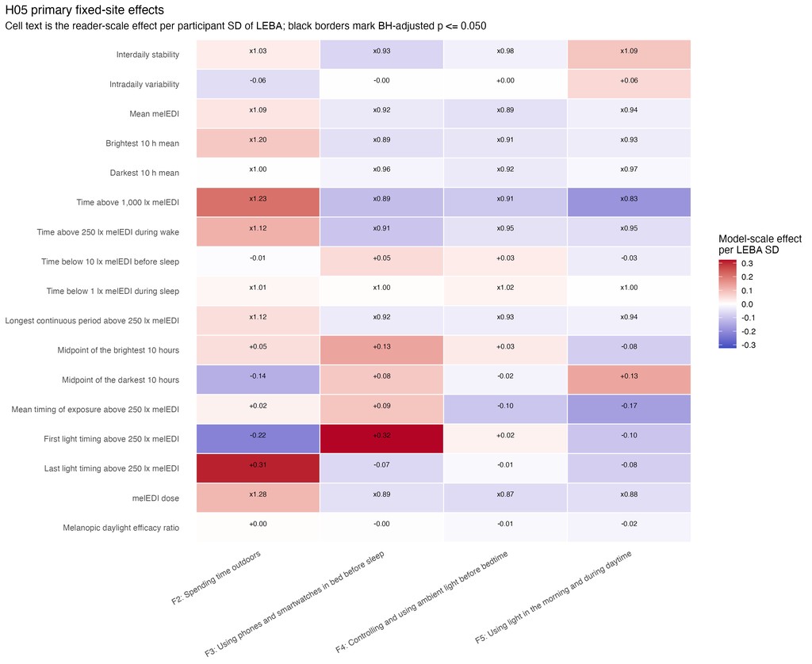

Primary fixed-site effects per participant SD of each LEBA factor. Cell text is on the reader-facing response scale. Colours show model-scale direction and magnitude and are not directly comparable between outcomes. No cell has a black multiplicity-retained border.

**F2 — time outdoors**

F2: Spending time outdoors

Fixed-site primary model; one 68-test BH family across all four tabs. BH-adjusted p is bold only at alpha = 0.050; Raw p has no bolding rule

| Metric | Effect per LEBA SD (95% CI) | Raw p | BH-adjusted p | Adequacy |
| --- | --- | --- | --- | --- |
| Interdaily stability | 1.028 × (0.956 to 1.106) | 0.445 | 0.658 | Acceptable |
| Interdaily stability | 0.931 × (0.868 to 0.999) | 0.042 | 0.260 | Acceptable |
| Interdaily stability | 0.975 × (0.906 to 1.050) | 0.489 | 0.679 | Acceptable |
| Interdaily stability | 1.089 × (1.011 to 1.174) | 0.021 | 0.202 | Acceptable |
| Intradaily variability | -0.057 (-0.124 to +0.009) | 0.083 | 0.351 | Acceptable |
| Intradaily variability | -0.001 (-0.068 to +0.065) | 0.971 | 0.978 | Acceptable |
| Intradaily variability | +0.001 (-0.068 to +0.069) | 0.978 | 0.978 | Acceptable |
| Intradaily variability | +0.057 (-0.013 to +0.127) | 0.099 | 0.362 | Acceptable |
| Mean melEDI | 1.092 × (0.965 to 1.235) | 0.150 | 0.379 | Acceptable with limitations |
| Mean melEDI | 0.917 × (0.813 to 1.034) | 0.146 | 0.379 | Acceptable with limitations |
| Mean melEDI | 0.891 × (0.787 to 1.009) | 0.060 | 0.313 | Acceptable with limitations |
| Mean melEDI | 0.941 × (0.827 to 1.070) | 0.336 | 0.585 | Acceptable with limitations |
| Brightest 10 h mean | 1.204 × (1.008 to 1.439) | 0.035 | 0.260 | Acceptable with limitations |
| Brightest 10 h mean | 0.888 × (0.745 to 1.058) | 0.169 | 0.384 | Acceptable with limitations |
| Brightest 10 h mean | 0.906 × (0.756 to 1.087) | 0.272 | 0.545 | Acceptable with limitations |
| Brightest 10 h mean | 0.931 × (0.772 to 1.123) | 0.436 | 0.658 | Acceptable with limitations |
| Darkest 10 h mean | 0.995 × (0.905 to 1.094) | 0.917 | 0.958 | Acceptable with limitations |
| Darkest 10 h mean | 0.956 × (0.871 to 1.049) | 0.322 | 0.577 | Acceptable with limitations |
| Darkest 10 h mean | 0.921 × (0.838 to 1.013) | 0.080 | 0.351 | Acceptable with limitations |
| Darkest 10 h mean | 0.970 × (0.879 to 1.070) | 0.526 | 0.716 | Acceptable with limitations |
| Time above 1,000 lx melEDI | 1.234 × (1.084 to 1.405) | 0.002 | 0.124 | Acceptable |
| Time above 1,000 lx melEDI | 0.895 × (0.785 to 1.020) | 0.097 | 0.362 | Acceptable |
| Time above 1,000 lx melEDI | 0.911 × (0.797 to 1.043) | 0.178 | 0.390 | Acceptable |
| Time above 1,000 lx melEDI | 0.831 × (0.725 to 0.953) | 0.009 | 0.169 | Acceptable |
| Time above 250 lx melEDI during wake | 1.122 × (1.006 to 1.252) | 0.041 | 0.260 | Acceptable with limitations |
| Time above 250 lx melEDI during wake | 0.907 × (0.814 to 1.010) | 0.075 | 0.351 | Acceptable |
| Time above 250 lx melEDI during wake | 0.953 × (0.852 to 1.065) | 0.397 | 0.614 | Acceptable |
| Time above 250 lx melEDI during wake | 0.946 × (0.843 to 1.061) | 0.345 | 0.586 | Acceptable |
| Time below 10 lx melEDI before sleep | -0.005 (-0.135 to +0.124) | 0.930 | 0.958 | Acceptable with limitations |
| Time below 10 lx melEDI before sleep | +0.052 (-0.073 to +0.177) | 0.392 | 0.614 | Acceptable with limitations |
| Time below 10 lx melEDI before sleep | +0.028 (-0.104 to +0.159) | 0.654 | 0.781 | Acceptable with limitations |
| Time below 10 lx melEDI before sleep | -0.031 (-0.167 to +0.105) | 0.646 | 0.781 | Acceptable with limitations |
| Time below 1 lx melEDI during sleep | 1.013 × (0.979 to 1.048) | 0.461 | 0.667 | Unfit for inference (author disposition) |
| Time below 1 lx melEDI during sleep | 1.003 × (0.970 to 1.038) | 0.841 | 0.937 | Unfit for inference (author disposition) |
| Time below 1 lx melEDI during sleep | 1.018 × (0.983 to 1.055) | 0.309 | 0.567 | Unfit for inference (author disposition) |
| Time below 1 lx melEDI during sleep | 0.998 × (0.962 to 1.035) | 0.906 | 0.958 | Unfit for inference (author disposition) |
| Longest continuous period above 250 lx melEDI | 1.117 × (1.007 to 1.238) | 0.031 | 0.260 | Acceptable |
| Longest continuous period above 250 lx melEDI | 0.924 × (0.835 to 1.023) | 0.117 | 0.375 | Acceptable |
| Longest continuous period above 250 lx melEDI | 0.933 × (0.840 to 1.037) | 0.185 | 0.393 | Acceptable |
| Longest continuous period above 250 lx melEDI | 0.945 × (0.847 to 1.053) | 0.287 | 0.557 | Acceptable |
| Midpoint of the brightest 10 hours | +0.049 (-0.132 to +0.229) | 0.584 | 0.747 | Acceptable with limitations |
| Midpoint of the brightest 10 hours | +0.133 (-0.042 to +0.309) | 0.124 | 0.375 | Acceptable with limitations |
| Midpoint of the brightest 10 hours | +0.030 (-0.153 to +0.213) | 0.740 | 0.868 | Acceptable with limitations |
| Midpoint of the brightest 10 hours | -0.083 (-0.270 to +0.105) | 0.371 | 0.601 | Acceptable with limitations |
| Midpoint of the darkest 10 hours | -0.136 (-0.317 to +0.044) | 0.127 | 0.375 | Acceptable with limitations |
| Midpoint of the darkest 10 hours | +0.080 (-0.097 to +0.258) | 0.358 | 0.594 | Acceptable with limitations |
| Midpoint of the darkest 10 hours | -0.020 (-0.204 to +0.164) | 0.825 | 0.935 | Acceptable with limitations |
| Midpoint of the darkest 10 hours | +0.132 (-0.056 to +0.320) | 0.156 | 0.379 | Acceptable with limitations |
| Mean timing of exposure above 250 lx melEDI | +0.020 (-0.152 to +0.192) | 0.819 | 0.935 | Acceptable with limitations |
| Mean timing of exposure above 250 lx melEDI | +0.086 (-0.081 to +0.253) | 0.295 | 0.558 | Acceptable with limitations |
| Mean timing of exposure above 250 lx melEDI | -0.097 (-0.267 to +0.074) | 0.247 | 0.510 | Acceptable with limitations |
| Mean timing of exposure above 250 lx melEDI | -0.166 (-0.339 to +0.008) | 0.053 | 0.301 | Acceptable with limitations |
| First light timing above 250 lx melEDI | -0.219 (-0.489 to +0.052) | 0.101 | 0.362 | Acceptable with limitations |
| First light timing above 250 lx melEDI | +0.324 (+0.062 to +0.585) | 0.013 | 0.179 | Acceptable with limitations |
| First light timing above 250 lx melEDI | +0.019 (-0.252 to +0.291) | 0.887 | 0.958 | Acceptable with limitations |
| First light timing above 250 lx melEDI | -0.097 (-0.380 to +0.185) | 0.486 | 0.679 | Acceptable with limitations |
| Last light timing above 250 lx melEDI | +0.308 (+0.043 to +0.573) | 0.020 | 0.202 | Acceptable with limitations |
| Last light timing above 250 lx melEDI | -0.066 (-0.328 to +0.196) | 0.615 | 0.760 | Acceptable with limitations |
| Last light timing above 250 lx melEDI | -0.011 (-0.280 to +0.259) | 0.927 | 0.958 | Acceptable with limitations |
| Last light timing above 250 lx melEDI | -0.081 (-0.361 to +0.200) | 0.558 | 0.743 | Acceptable with limitations |
| melEDI dose | 1.278 × (1.079 to 1.514) | 0.004 | 0.124 | Acceptable with limitations |
| melEDI dose | 0.885 × (0.748 to 1.048) | 0.143 | 0.379 | Acceptable with limitations |
| melEDI dose | 0.872 × (0.732 to 1.038) | 0.112 | 0.375 | Acceptable with limitations |
| melEDI dose | 0.881 × (0.736 to 1.054) | 0.153 | 0.379 | Acceptable with limitations |
| Melanopic daylight efficacy ratio | +0.004 (-0.011 to +0.019) | 0.586 | 0.747 | Acceptable with limitations |
| Melanopic daylight efficacy ratio | -0.004 (-0.019 to +0.011) | 0.593 | 0.747 | Acceptable with limitations |
| Melanopic daylight efficacy ratio | -0.010 (-0.026 to +0.005) | 0.162 | 0.380 | Acceptable with limitations |
| Melanopic daylight efficacy ratio | -0.020 (-0.035 to -0.004) | 0.010 | 0.169 | Acceptable with limitations |

**F3 — devices in bed**

F3: Using phones and smartwatches in bed before sleep

Fixed-site primary model; one 68-test BH family across all four tabs. BH-adjusted p is bold only at alpha = 0.050; Raw p has no bolding rule

| Metric | Effect per LEBA SD (95% CI) | Raw p | BH-adjusted p | Adequacy |
| --- | --- | --- | --- | --- |
| Interdaily stability | 1.028 × (0.956 to 1.106) | 0.445 | 0.658 | Acceptable |
| Interdaily stability | 0.931 × (0.868 to 0.999) | 0.042 | 0.260 | Acceptable |
| Interdaily stability | 0.975 × (0.906 to 1.050) | 0.489 | 0.679 | Acceptable |
| Interdaily stability | 1.089 × (1.011 to 1.174) | 0.021 | 0.202 | Acceptable |
| Intradaily variability | -0.057 (-0.124 to +0.009) | 0.083 | 0.351 | Acceptable |
| Intradaily variability | -0.001 (-0.068 to +0.065) | 0.971 | 0.978 | Acceptable |
| Intradaily variability | +0.001 (-0.068 to +0.069) | 0.978 | 0.978 | Acceptable |
| Intradaily variability | +0.057 (-0.013 to +0.127) | 0.099 | 0.362 | Acceptable |
| Mean melEDI | 1.092 × (0.965 to 1.235) | 0.150 | 0.379 | Acceptable with limitations |
| Mean melEDI | 0.917 × (0.813 to 1.034) | 0.146 | 0.379 | Acceptable with limitations |
| Mean melEDI | 0.891 × (0.787 to 1.009) | 0.060 | 0.313 | Acceptable with limitations |
| Mean melEDI | 0.941 × (0.827 to 1.070) | 0.336 | 0.585 | Acceptable with limitations |
| Brightest 10 h mean | 1.204 × (1.008 to 1.439) | 0.035 | 0.260 | Acceptable with limitations |
| Brightest 10 h mean | 0.888 × (0.745 to 1.058) | 0.169 | 0.384 | Acceptable with limitations |
| Brightest 10 h mean | 0.906 × (0.756 to 1.087) | 0.272 | 0.545 | Acceptable with limitations |
| Brightest 10 h mean | 0.931 × (0.772 to 1.123) | 0.436 | 0.658 | Acceptable with limitations |
| Darkest 10 h mean | 0.995 × (0.905 to 1.094) | 0.917 | 0.958 | Acceptable with limitations |
| Darkest 10 h mean | 0.956 × (0.871 to 1.049) | 0.322 | 0.577 | Acceptable with limitations |
| Darkest 10 h mean | 0.921 × (0.838 to 1.013) | 0.080 | 0.351 | Acceptable with limitations |
| Darkest 10 h mean | 0.970 × (0.879 to 1.070) | 0.526 | 0.716 | Acceptable with limitations |
| Time above 1,000 lx melEDI | 1.234 × (1.084 to 1.405) | 0.002 | 0.124 | Acceptable |
| Time above 1,000 lx melEDI | 0.895 × (0.785 to 1.020) | 0.097 | 0.362 | Acceptable |
| Time above 1,000 lx melEDI | 0.911 × (0.797 to 1.043) | 0.178 | 0.390 | Acceptable |
| Time above 1,000 lx melEDI | 0.831 × (0.725 to 0.953) | 0.009 | 0.169 | Acceptable |
| Time above 250 lx melEDI during wake | 1.122 × (1.006 to 1.252) | 0.041 | 0.260 | Acceptable with limitations |
| Time above 250 lx melEDI during wake | 0.907 × (0.814 to 1.010) | 0.075 | 0.351 | Acceptable |
| Time above 250 lx melEDI during wake | 0.953 × (0.852 to 1.065) | 0.397 | 0.614 | Acceptable |
| Time above 250 lx melEDI during wake | 0.946 × (0.843 to 1.061) | 0.345 | 0.586 | Acceptable |
| Time below 10 lx melEDI before sleep | -0.005 (-0.135 to +0.124) | 0.930 | 0.958 | Acceptable with limitations |
| Time below 10 lx melEDI before sleep | +0.052 (-0.073 to +0.177) | 0.392 | 0.614 | Acceptable with limitations |
| Time below 10 lx melEDI before sleep | +0.028 (-0.104 to +0.159) | 0.654 | 0.781 | Acceptable with limitations |
| Time below 10 lx melEDI before sleep | -0.031 (-0.167 to +0.105) | 0.646 | 0.781 | Acceptable with limitations |
| Time below 1 lx melEDI during sleep | 1.013 × (0.979 to 1.048) | 0.461 | 0.667 | Unfit for inference (author disposition) |
| Time below 1 lx melEDI during sleep | 1.003 × (0.970 to 1.038) | 0.841 | 0.937 | Unfit for inference (author disposition) |
| Time below 1 lx melEDI during sleep | 1.018 × (0.983 to 1.055) | 0.309 | 0.567 | Unfit for inference (author disposition) |
| Time below 1 lx melEDI during sleep | 0.998 × (0.962 to 1.035) | 0.906 | 0.958 | Unfit for inference (author disposition) |
| Longest continuous period above 250 lx melEDI | 1.117 × (1.007 to 1.238) | 0.031 | 0.260 | Acceptable |
| Longest continuous period above 250 lx melEDI | 0.924 × (0.835 to 1.023) | 0.117 | 0.375 | Acceptable |
| Longest continuous period above 250 lx melEDI | 0.933 × (0.840 to 1.037) | 0.185 | 0.393 | Acceptable |
| Longest continuous period above 250 lx melEDI | 0.945 × (0.847 to 1.053) | 0.287 | 0.557 | Acceptable |
| Midpoint of the brightest 10 hours | +0.049 (-0.132 to +0.229) | 0.584 | 0.747 | Acceptable with limitations |
| Midpoint of the brightest 10 hours | +0.133 (-0.042 to +0.309) | 0.124 | 0.375 | Acceptable with limitations |
| Midpoint of the brightest 10 hours | +0.030 (-0.153 to +0.213) | 0.740 | 0.868 | Acceptable with limitations |
| Midpoint of the brightest 10 hours | -0.083 (-0.270 to +0.105) | 0.371 | 0.601 | Acceptable with limitations |
| Midpoint of the darkest 10 hours | -0.136 (-0.317 to +0.044) | 0.127 | 0.375 | Acceptable with limitations |
| Midpoint of the darkest 10 hours | +0.080 (-0.097 to +0.258) | 0.358 | 0.594 | Acceptable with limitations |
| Midpoint of the darkest 10 hours | -0.020 (-0.204 to +0.164) | 0.825 | 0.935 | Acceptable with limitations |
| Midpoint of the darkest 10 hours | +0.132 (-0.056 to +0.320) | 0.156 | 0.379 | Acceptable with limitations |
| Mean timing of exposure above 250 lx melEDI | +0.020 (-0.152 to +0.192) | 0.819 | 0.935 | Acceptable with limitations |
| Mean timing of exposure above 250 lx melEDI | +0.086 (-0.081 to +0.253) | 0.295 | 0.558 | Acceptable with limitations |
| Mean timing of exposure above 250 lx melEDI | -0.097 (-0.267 to +0.074) | 0.247 | 0.510 | Acceptable with limitations |
| Mean timing of exposure above 250 lx melEDI | -0.166 (-0.339 to +0.008) | 0.053 | 0.301 | Acceptable with limitations |
| First light timing above 250 lx melEDI | -0.219 (-0.489 to +0.052) | 0.101 | 0.362 | Acceptable with limitations |
| First light timing above 250 lx melEDI | +0.324 (+0.062 to +0.585) | 0.013 | 0.179 | Acceptable with limitations |
| First light timing above 250 lx melEDI | +0.019 (-0.252 to +0.291) | 0.887 | 0.958 | Acceptable with limitations |
| First light timing above 250 lx melEDI | -0.097 (-0.380 to +0.185) | 0.486 | 0.679 | Acceptable with limitations |
| Last light timing above 250 lx melEDI | +0.308 (+0.043 to +0.573) | 0.020 | 0.202 | Acceptable with limitations |
| Last light timing above 250 lx melEDI | -0.066 (-0.328 to +0.196) | 0.615 | 0.760 | Acceptable with limitations |
| Last light timing above 250 lx melEDI | -0.011 (-0.280 to +0.259) | 0.927 | 0.958 | Acceptable with limitations |
| Last light timing above 250 lx melEDI | -0.081 (-0.361 to +0.200) | 0.558 | 0.743 | Acceptable with limitations |
| melEDI dose | 1.278 × (1.079 to 1.514) | 0.004 | 0.124 | Acceptable with limitations |
| melEDI dose | 0.885 × (0.748 to 1.048) | 0.143 | 0.379 | Acceptable with limitations |
| melEDI dose | 0.872 × (0.732 to 1.038) | 0.112 | 0.375 | Acceptable with limitations |
| melEDI dose | 0.881 × (0.736 to 1.054) | 0.153 | 0.379 | Acceptable with limitations |
| Melanopic daylight efficacy ratio | +0.004 (-0.011 to +0.019) | 0.586 | 0.747 | Acceptable with limitations |
| Melanopic daylight efficacy ratio | -0.004 (-0.019 to +0.011) | 0.593 | 0.747 | Acceptable with limitations |
| Melanopic daylight efficacy ratio | -0.010 (-0.026 to +0.005) | 0.162 | 0.380 | Acceptable with limitations |
| Melanopic daylight efficacy ratio | -0.020 (-0.035 to -0.004) | 0.010 | 0.169 | Acceptable with limitations |

**F4 — ambient light before bedtime**

F4: Controlling and using ambient light before bedtime

Fixed-site primary model; one 68-test BH family across all four tabs. BH-adjusted p is bold only at alpha = 0.050; Raw p has no bolding rule

| Metric | Effect per LEBA SD (95% CI) | Raw p | BH-adjusted p | Adequacy |
| --- | --- | --- | --- | --- |
| Interdaily stability | 1.028 × (0.956 to 1.106) | 0.445 | 0.658 | Acceptable |
| Interdaily stability | 0.931 × (0.868 to 0.999) | 0.042 | 0.260 | Acceptable |
| Interdaily stability | 0.975 × (0.906 to 1.050) | 0.489 | 0.679 | Acceptable |
| Interdaily stability | 1.089 × (1.011 to 1.174) | 0.021 | 0.202 | Acceptable |
| Intradaily variability | -0.057 (-0.124 to +0.009) | 0.083 | 0.351 | Acceptable |
| Intradaily variability | -0.001 (-0.068 to +0.065) | 0.971 | 0.978 | Acceptable |
| Intradaily variability | +0.001 (-0.068 to +0.069) | 0.978 | 0.978 | Acceptable |
| Intradaily variability | +0.057 (-0.013 to +0.127) | 0.099 | 0.362 | Acceptable |
| Mean melEDI | 1.092 × (0.965 to 1.235) | 0.150 | 0.379 | Acceptable with limitations |
| Mean melEDI | 0.917 × (0.813 to 1.034) | 0.146 | 0.379 | Acceptable with limitations |
| Mean melEDI | 0.891 × (0.787 to 1.009) | 0.060 | 0.313 | Acceptable with limitations |
| Mean melEDI | 0.941 × (0.827 to 1.070) | 0.336 | 0.585 | Acceptable with limitations |
| Brightest 10 h mean | 1.204 × (1.008 to 1.439) | 0.035 | 0.260 | Acceptable with limitations |
| Brightest 10 h mean | 0.888 × (0.745 to 1.058) | 0.169 | 0.384 | Acceptable with limitations |
| Brightest 10 h mean | 0.906 × (0.756 to 1.087) | 0.272 | 0.545 | Acceptable with limitations |
| Brightest 10 h mean | 0.931 × (0.772 to 1.123) | 0.436 | 0.658 | Acceptable with limitations |
| Darkest 10 h mean | 0.995 × (0.905 to 1.094) | 0.917 | 0.958 | Acceptable with limitations |
| Darkest 10 h mean | 0.956 × (0.871 to 1.049) | 0.322 | 0.577 | Acceptable with limitations |
| Darkest 10 h mean | 0.921 × (0.838 to 1.013) | 0.080 | 0.351 | Acceptable with limitations |
| Darkest 10 h mean | 0.970 × (0.879 to 1.070) | 0.526 | 0.716 | Acceptable with limitations |
| Time above 1,000 lx melEDI | 1.234 × (1.084 to 1.405) | 0.002 | 0.124 | Acceptable |
| Time above 1,000 lx melEDI | 0.895 × (0.785 to 1.020) | 0.097 | 0.362 | Acceptable |
| Time above 1,000 lx melEDI | 0.911 × (0.797 to 1.043) | 0.178 | 0.390 | Acceptable |
| Time above 1,000 lx melEDI | 0.831 × (0.725 to 0.953) | 0.009 | 0.169 | Acceptable |
| Time above 250 lx melEDI during wake | 1.122 × (1.006 to 1.252) | 0.041 | 0.260 | Acceptable with limitations |
| Time above 250 lx melEDI during wake | 0.907 × (0.814 to 1.010) | 0.075 | 0.351 | Acceptable |
| Time above 250 lx melEDI during wake | 0.953 × (0.852 to 1.065) | 0.397 | 0.614 | Acceptable |
| Time above 250 lx melEDI during wake | 0.946 × (0.843 to 1.061) | 0.345 | 0.586 | Acceptable |
| Time below 10 lx melEDI before sleep | -0.005 (-0.135 to +0.124) | 0.930 | 0.958 | Acceptable with limitations |
| Time below 10 lx melEDI before sleep | +0.052 (-0.073 to +0.177) | 0.392 | 0.614 | Acceptable with limitations |
| Time below 10 lx melEDI before sleep | +0.028 (-0.104 to +0.159) | 0.654 | 0.781 | Acceptable with limitations |
| Time below 10 lx melEDI before sleep | -0.031 (-0.167 to +0.105) | 0.646 | 0.781 | Acceptable with limitations |
| Time below 1 lx melEDI during sleep | 1.013 × (0.979 to 1.048) | 0.461 | 0.667 | Unfit for inference (author disposition) |
| Time below 1 lx melEDI during sleep | 1.003 × (0.970 to 1.038) | 0.841 | 0.937 | Unfit for inference (author disposition) |
| Time below 1 lx melEDI during sleep | 1.018 × (0.983 to 1.055) | 0.309 | 0.567 | Unfit for inference (author disposition) |
| Time below 1 lx melEDI during sleep | 0.998 × (0.962 to 1.035) | 0.906 | 0.958 | Unfit for inference (author disposition) |
| Longest continuous period above 250 lx melEDI | 1.117 × (1.007 to 1.238) | 0.031 | 0.260 | Acceptable |
| Longest continuous period above 250 lx melEDI | 0.924 × (0.835 to 1.023) | 0.117 | 0.375 | Acceptable |
| Longest continuous period above 250 lx melEDI | 0.933 × (0.840 to 1.037) | 0.185 | 0.393 | Acceptable |
| Longest continuous period above 250 lx melEDI | 0.945 × (0.847 to 1.053) | 0.287 | 0.557 | Acceptable |
| Midpoint of the brightest 10 hours | +0.049 (-0.132 to +0.229) | 0.584 | 0.747 | Acceptable with limitations |
| Midpoint of the brightest 10 hours | +0.133 (-0.042 to +0.309) | 0.124 | 0.375 | Acceptable with limitations |
| Midpoint of the brightest 10 hours | +0.030 (-0.153 to +0.213) | 0.740 | 0.868 | Acceptable with limitations |
| Midpoint of the brightest 10 hours | -0.083 (-0.270 to +0.105) | 0.371 | 0.601 | Acceptable with limitations |
| Midpoint of the darkest 10 hours | -0.136 (-0.317 to +0.044) | 0.127 | 0.375 | Acceptable with limitations |
| Midpoint of the darkest 10 hours | +0.080 (-0.097 to +0.258) | 0.358 | 0.594 | Acceptable with limitations |
| Midpoint of the darkest 10 hours | -0.020 (-0.204 to +0.164) | 0.825 | 0.935 | Acceptable with limitations |
| Midpoint of the darkest 10 hours | +0.132 (-0.056 to +0.320) | 0.156 | 0.379 | Acceptable with limitations |
| Mean timing of exposure above 250 lx melEDI | +0.020 (-0.152 to +0.192) | 0.819 | 0.935 | Acceptable with limitations |
| Mean timing of exposure above 250 lx melEDI | +0.086 (-0.081 to +0.253) | 0.295 | 0.558 | Acceptable with limitations |
| Mean timing of exposure above 250 lx melEDI | -0.097 (-0.267 to +0.074) | 0.247 | 0.510 | Acceptable with limitations |
| Mean timing of exposure above 250 lx melEDI | -0.166 (-0.339 to +0.008) | 0.053 | 0.301 | Acceptable with limitations |
| First light timing above 250 lx melEDI | -0.219 (-0.489 to +0.052) | 0.101 | 0.362 | Acceptable with limitations |
| First light timing above 250 lx melEDI | +0.324 (+0.062 to +0.585) | 0.013 | 0.179 | Acceptable with limitations |
| First light timing above 250 lx melEDI | +0.019 (-0.252 to +0.291) | 0.887 | 0.958 | Acceptable with limitations |
| First light timing above 250 lx melEDI | -0.097 (-0.380 to +0.185) | 0.486 | 0.679 | Acceptable with limitations |
| Last light timing above 250 lx melEDI | +0.308 (+0.043 to +0.573) | 0.020 | 0.202 | Acceptable with limitations |
| Last light timing above 250 lx melEDI | -0.066 (-0.328 to +0.196) | 0.615 | 0.760 | Acceptable with limitations |
| Last light timing above 250 lx melEDI | -0.011 (-0.280 to +0.259) | 0.927 | 0.958 | Acceptable with limitations |
| Last light timing above 250 lx melEDI | -0.081 (-0.361 to +0.200) | 0.558 | 0.743 | Acceptable with limitations |
| melEDI dose | 1.278 × (1.079 to 1.514) | 0.004 | 0.124 | Acceptable with limitations |
| melEDI dose | 0.885 × (0.748 to 1.048) | 0.143 | 0.379 | Acceptable with limitations |
| melEDI dose | 0.872 × (0.732 to 1.038) | 0.112 | 0.375 | Acceptable with limitations |
| melEDI dose | 0.881 × (0.736 to 1.054) | 0.153 | 0.379 | Acceptable with limitations |
| Melanopic daylight efficacy ratio | +0.004 (-0.011 to +0.019) | 0.586 | 0.747 | Acceptable with limitations |
| Melanopic daylight efficacy ratio | -0.004 (-0.019 to +0.011) | 0.593 | 0.747 | Acceptable with limitations |
| Melanopic daylight efficacy ratio | -0.010 (-0.026 to +0.005) | 0.162 | 0.380 | Acceptable with limitations |
| Melanopic daylight efficacy ratio | -0.020 (-0.035 to -0.004) | 0.010 | 0.169 | Acceptable with limitations |

**F5 — morning/daytime light use**

F5: Using light in the morning and during daytime

Fixed-site primary model; one 68-test BH family across all four tabs. BH-adjusted p is bold only at alpha = 0.050; Raw p has no bolding rule

| Metric | Effect per LEBA SD (95% CI) | Raw p | BH-adjusted p | Adequacy |
| --- | --- | --- | --- | --- |
| Interdaily stability | 1.028 × (0.956 to 1.106) | 0.445 | 0.658 | Acceptable |
| Interdaily stability | 0.931 × (0.868 to 0.999) | 0.042 | 0.260 | Acceptable |
| Interdaily stability | 0.975 × (0.906 to 1.050) | 0.489 | 0.679 | Acceptable |
| Interdaily stability | 1.089 × (1.011 to 1.174) | 0.021 | 0.202 | Acceptable |
| Intradaily variability | -0.057 (-0.124 to +0.009) | 0.083 | 0.351 | Acceptable |
| Intradaily variability | -0.001 (-0.068 to +0.065) | 0.971 | 0.978 | Acceptable |
| Intradaily variability | +0.001 (-0.068 to +0.069) | 0.978 | 0.978 | Acceptable |
| Intradaily variability | +0.057 (-0.013 to +0.127) | 0.099 | 0.362 | Acceptable |
| Mean melEDI | 1.092 × (0.965 to 1.235) | 0.150 | 0.379 | Acceptable with limitations |
| Mean melEDI | 0.917 × (0.813 to 1.034) | 0.146 | 0.379 | Acceptable with limitations |
| Mean melEDI | 0.891 × (0.787 to 1.009) | 0.060 | 0.313 | Acceptable with limitations |
| Mean melEDI | 0.941 × (0.827 to 1.070) | 0.336 | 0.585 | Acceptable with limitations |
| Brightest 10 h mean | 1.204 × (1.008 to 1.439) | 0.035 | 0.260 | Acceptable with limitations |
| Brightest 10 h mean | 0.888 × (0.745 to 1.058) | 0.169 | 0.384 | Acceptable with limitations |
| Brightest 10 h mean | 0.906 × (0.756 to 1.087) | 0.272 | 0.545 | Acceptable with limitations |
| Brightest 10 h mean | 0.931 × (0.772 to 1.123) | 0.436 | 0.658 | Acceptable with limitations |
| Darkest 10 h mean | 0.995 × (0.905 to 1.094) | 0.917 | 0.958 | Acceptable with limitations |
| Darkest 10 h mean | 0.956 × (0.871 to 1.049) | 0.322 | 0.577 | Acceptable with limitations |
| Darkest 10 h mean | 0.921 × (0.838 to 1.013) | 0.080 | 0.351 | Acceptable with limitations |
| Darkest 10 h mean | 0.970 × (0.879 to 1.070) | 0.526 | 0.716 | Acceptable with limitations |
| Time above 1,000 lx melEDI | 1.234 × (1.084 to 1.405) | 0.002 | 0.124 | Acceptable |
| Time above 1,000 lx melEDI | 0.895 × (0.785 to 1.020) | 0.097 | 0.362 | Acceptable |
| Time above 1,000 lx melEDI | 0.911 × (0.797 to 1.043) | 0.178 | 0.390 | Acceptable |
| Time above 1,000 lx melEDI | 0.831 × (0.725 to 0.953) | 0.009 | 0.169 | Acceptable |
| Time above 250 lx melEDI during wake | 1.122 × (1.006 to 1.252) | 0.041 | 0.260 | Acceptable with limitations |
| Time above 250 lx melEDI during wake | 0.907 × (0.814 to 1.010) | 0.075 | 0.351 | Acceptable |
| Time above 250 lx melEDI during wake | 0.953 × (0.852 to 1.065) | 0.397 | 0.614 | Acceptable |
| Time above 250 lx melEDI during wake | 0.946 × (0.843 to 1.061) | 0.345 | 0.586 | Acceptable |
| Time below 10 lx melEDI before sleep | -0.005 (-0.135 to +0.124) | 0.930 | 0.958 | Acceptable with limitations |
| Time below 10 lx melEDI before sleep | +0.052 (-0.073 to +0.177) | 0.392 | 0.614 | Acceptable with limitations |
| Time below 10 lx melEDI before sleep | +0.028 (-0.104 to +0.159) | 0.654 | 0.781 | Acceptable with limitations |
| Time below 10 lx melEDI before sleep | -0.031 (-0.167 to +0.105) | 0.646 | 0.781 | Acceptable with limitations |
| Time below 1 lx melEDI during sleep | 1.013 × (0.979 to 1.048) | 0.461 | 0.667 | Unfit for inference (author disposition) |
| Time below 1 lx melEDI during sleep | 1.003 × (0.970 to 1.038) | 0.841 | 0.937 | Unfit for inference (author disposition) |
| Time below 1 lx melEDI during sleep | 1.018 × (0.983 to 1.055) | 0.309 | 0.567 | Unfit for inference (author disposition) |
| Time below 1 lx melEDI during sleep | 0.998 × (0.962 to 1.035) | 0.906 | 0.958 | Unfit for inference (author disposition) |
| Longest continuous period above 250 lx melEDI | 1.117 × (1.007 to 1.238) | 0.031 | 0.260 | Acceptable |
| Longest continuous period above 250 lx melEDI | 0.924 × (0.835 to 1.023) | 0.117 | 0.375 | Acceptable |
| Longest continuous period above 250 lx melEDI | 0.933 × (0.840 to 1.037) | 0.185 | 0.393 | Acceptable |
| Longest continuous period above 250 lx melEDI | 0.945 × (0.847 to 1.053) | 0.287 | 0.557 | Acceptable |
| Midpoint of the brightest 10 hours | +0.049 (-0.132 to +0.229) | 0.584 | 0.747 | Acceptable with limitations |
| Midpoint of the brightest 10 hours | +0.133 (-0.042 to +0.309) | 0.124 | 0.375 | Acceptable with limitations |
| Midpoint of the brightest 10 hours | +0.030 (-0.153 to +0.213) | 0.740 | 0.868 | Acceptable with limitations |
| Midpoint of the brightest 10 hours | -0.083 (-0.270 to +0.105) | 0.371 | 0.601 | Acceptable with limitations |
| Midpoint of the darkest 10 hours | -0.136 (-0.317 to +0.044) | 0.127 | 0.375 | Acceptable with limitations |
| Midpoint of the darkest 10 hours | +0.080 (-0.097 to +0.258) | 0.358 | 0.594 | Acceptable with limitations |
| Midpoint of the darkest 10 hours | -0.020 (-0.204 to +0.164) | 0.825 | 0.935 | Acceptable with limitations |
| Midpoint of the darkest 10 hours | +0.132 (-0.056 to +0.320) | 0.156 | 0.379 | Acceptable with limitations |
| Mean timing of exposure above 250 lx melEDI | +0.020 (-0.152 to +0.192) | 0.819 | 0.935 | Acceptable with limitations |
| Mean timing of exposure above 250 lx melEDI | +0.086 (-0.081 to +0.253) | 0.295 | 0.558 | Acceptable with limitations |
| Mean timing of exposure above 250 lx melEDI | -0.097 (-0.267 to +0.074) | 0.247 | 0.510 | Acceptable with limitations |
| Mean timing of exposure above 250 lx melEDI | -0.166 (-0.339 to +0.008) | 0.053 | 0.301 | Acceptable with limitations |
| First light timing above 250 lx melEDI | -0.219 (-0.489 to +0.052) | 0.101 | 0.362 | Acceptable with limitations |
| First light timing above 250 lx melEDI | +0.324 (+0.062 to +0.585) | 0.013 | 0.179 | Acceptable with limitations |
| First light timing above 250 lx melEDI | +0.019 (-0.252 to +0.291) | 0.887 | 0.958 | Acceptable with limitations |
| First light timing above 250 lx melEDI | -0.097 (-0.380 to +0.185) | 0.486 | 0.679 | Acceptable with limitations |
| Last light timing above 250 lx melEDI | +0.308 (+0.043 to +0.573) | 0.020 | 0.202 | Acceptable with limitations |
| Last light timing above 250 lx melEDI | -0.066 (-0.328 to +0.196) | 0.615 | 0.760 | Acceptable with limitations |
| Last light timing above 250 lx melEDI | -0.011 (-0.280 to +0.259) | 0.927 | 0.958 | Acceptable with limitations |
| Last light timing above 250 lx melEDI | -0.081 (-0.361 to +0.200) | 0.558 | 0.743 | Acceptable with limitations |
| melEDI dose | 1.278 × (1.079 to 1.514) | 0.004 | 0.124 | Acceptable with limitations |
| melEDI dose | 0.885 × (0.748 to 1.048) | 0.143 | 0.379 | Acceptable with limitations |
| melEDI dose | 0.872 × (0.732 to 1.038) | 0.112 | 0.375 | Acceptable with limitations |
| melEDI dose | 0.881 × (0.736 to 1.054) | 0.153 | 0.379 | Acceptable with limitations |
| Melanopic daylight efficacy ratio | +0.004 (-0.011 to +0.019) | 0.586 | 0.747 | Acceptable with limitations |
| Melanopic daylight efficacy ratio | -0.004 (-0.019 to +0.011) | 0.593 | 0.747 | Acceptable with limitations |
| Melanopic daylight efficacy ratio | -0.010 (-0.026 to +0.005) | 0.162 | 0.380 | Acceptable with limitations |
| Melanopic daylight efficacy ratio | -0.020 (-0.035 to -0.004) | 0.010 | 0.169 | Acceptable with limitations |

## Diagnostics and model adequacy

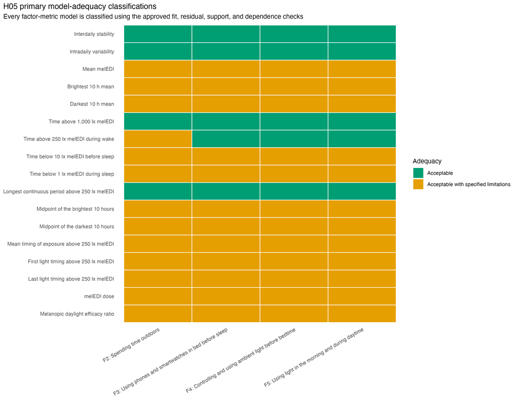

All fixed-site primary fits converge, have positive-definite Hessians where applicable, and are nonsingular. No observed response violates its declared physical bound, and no clock metric triggers the continuous-range stop rule. The 49 limitation classifications comprise:

- 44 ordinary Gaussian residual warnings, generally driven by sensitive normality or moderate variance/tail diagnostics rather than fit failure;
- one ordinary Tweedie warning for F2 with time above 250 lx melEDI during wake (DHARMa uniformity Raw p = 0.006); and
- four material Tweedie warnings for time below 1 lx melEDI during sleep, one for each factor.

Unfit sleep-environment models

Raw diagnostic p-values have no standalone alpha or bolding rule; joint residual and support failures make these models unfit for inference

| Factor | DHARMa uniformity Raw p | DHARMa zero-mass Raw p | DHARMa outlier Raw p | Observed zero fraction | Simulated zero fraction | Predicted above support | Reader disposition |
| --- | --- | --- | --- | --- | --- | --- | --- |
| F2: Spending time outdoors | <0.001 | <0.001 | <0.001 | 0.0051 | 0.0000 | 186 | Unfit for inference |
| F3: Using phones and smartwatches in bed before sleep | <0.001 | <0.001 | 0.002 | 0.0051 | 0.0000 | 186 | Unfit for inference |
| F4: Controlling and using ambient light before bedtime | <0.001 | <0.001 | 0.002 | 0.0051 | 0.0000 | 187 | Unfit for inference |
| F5: Using light in the morning and during daytime | <0.001 | <0.001 | <0.001 | 0.0051 | 0.0000 | 183 | Unfit for inference |

### Selected residual patterns

The following screens show the two strongest F2 models and the unfit sleep-environment model. For the Tweedie model, the numerical DHARMa tests above are the governing simulation-based diagnostics; the displayed Pearson-residual plots are supporting pattern checks.

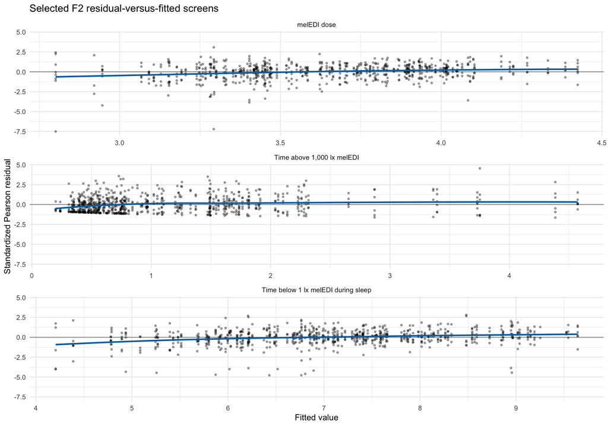

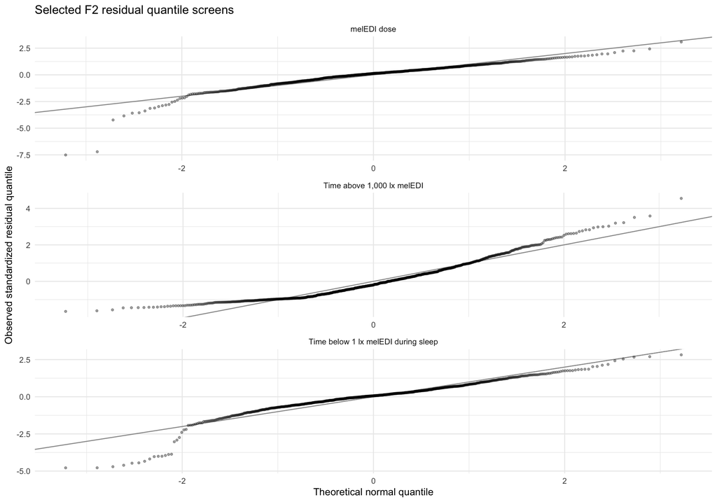

## V0 reproduction and direct comparison

### Faithful and corrected V0 matrices

Stage 2 independently reconstructs all 136 V0 placement–metric–factor cells from the two frozen workspaces. The faithful displays preserve V0’s Spearman coefficient paired with a default-Pearson test and cell-wise scalar `p.adjust(..., n = 68)`. The corrected displays use a consistent two-sided Spearman test and one vector-wide 68-cell BH adjustment. Labels and signed colour improve readability; no scientific value is changed in the faithful version.

**Near-eye faithful**

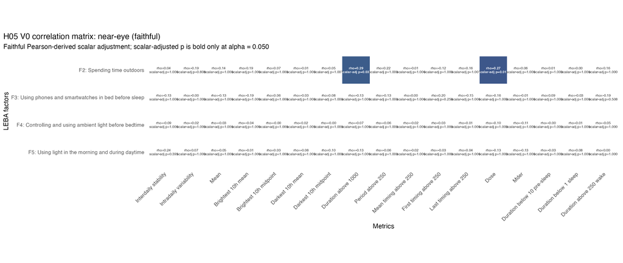

Faithful near-eye reconstruction. Cell annotations show Spearman rho and the Pearson-derived scalar-adjusted p; only values meeting its displayed alpha = 0.050 rule are bold.

**Near-eye corrected**

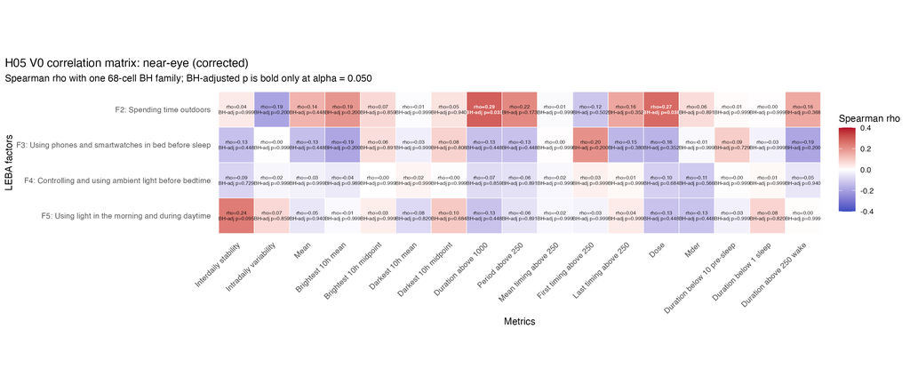

Corrected near-eye reconstruction. Cell annotations show Spearman rho and BH-adjusted p from one 68-test family; only BH-adjusted p at or below 0.050 is bold.

**Chest faithful**

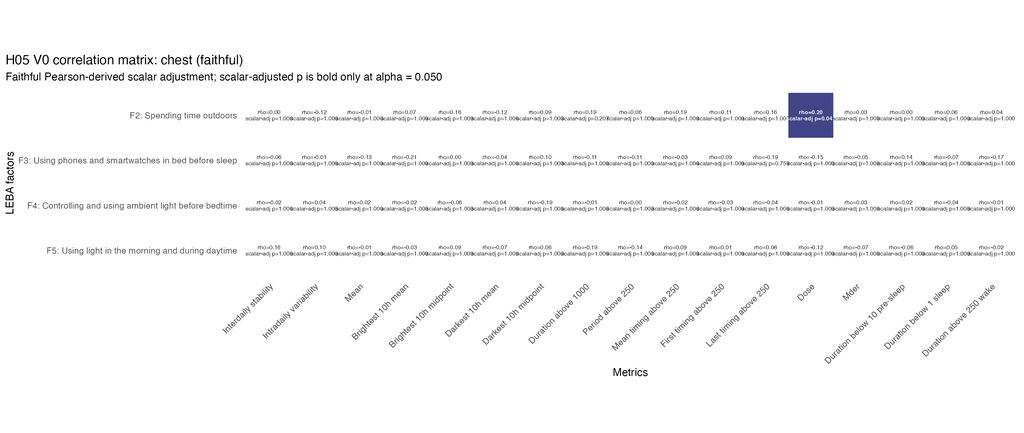

Faithful chest reconstruction. Cell annotations show Spearman rho and the Pearson-derived scalar-adjusted p; only values meeting its displayed alpha = 0.050 rule are bold.

**Chest corrected**

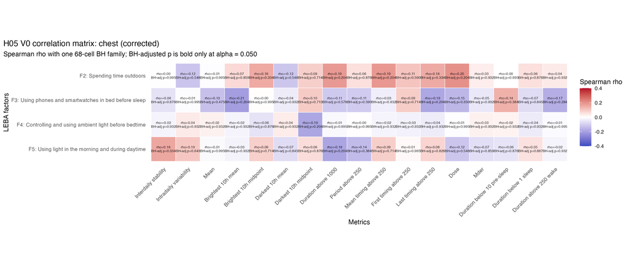

Corrected chest reconstruction. Cell annotations show Spearman rho and BH-adjusted p from one 68-test family; only BH-adjusted p at or below 0.050 is bold.

The faithful V0 near-eye matrix flags F2 with dose and time above 1,000 lx. The consistent V0 calculation also retains those two, with BH-adjusted p = 0.038 and 0.033, respectively. The faithful chest display flags F2 with dose; its consistent Spearman/vector-BH value is BH-adjusted p = 0.204, so no chest cell remains. This reconciliation does not validate V0 because V0 omits the registered site-adjusted outcome model and uses superseded metric inputs.

### The two V0 highlights under the approved analysis

V0 highlights versus the approved H05 implementation

BH-adjusted p is bold only at alpha = 0.050; Primary Raw p and descriptive rho have no separate significance styling

| Metric | V0 rho (BH-adjusted p) | New descriptive rho (95% CI) | Primary fixed-site effect per SD (95% CI) | Primary Raw p | Primary BH-adjusted p | Adequacy |
| --- | --- | --- | --- | --- | --- | --- |
| Time above 1,000 lx melEDI | 0.290 (BH-adjusted p = **0.033**) | 0.291 (0.132 to 0.436) | 1.234 × (1.084 to 1.405) | 0.002 | 0.124 | acceptable |
| melEDI dose | 0.272 (BH-adjusted p = **0.038**) | 0.263 (0.102 to 0.410) | 1.278 × (1.079 to 1.514) | 0.004 | 0.124 | acceptable_with_specified_limitations |

The repaired participant-summary coefficients are close to V0 for these two cells, but the approved estimand is the site-adjusted participant-day model. Neither primary model survives the declared 68-test family. The submitted phrase “duration above 250 lx” remains incorrect for the highlighted 1,000-lx outcome, and squared Spearman rho must not be described as variance explained.

## Sensitivity analyses

### Registered random-site model

H05 fits the registered random-site form for all 136 main all-available cells (68 per placement) without a second significance screen. Fifteen are descriptively unstable: eight chest cells and seven near-eye cells, chiefly zero or near-zero site variance. The fixed-site primary fits remain estimable. The two leading F2 estimates are stable and slightly larger under random site.

Registered random-site sensitivity for the two leading F2 estimates

No sensitivity p-values or significance screen

| Metric | Site random-effect SD | Random-site effect per SD (95% CI) | Status | Stability |
| --- | --- | --- | --- | --- |
| Time above 1,000 lx melEDI | 0.283 | 1.260 × (1.103 to 1.439) | DESCRIPTIVE_PASS | stable |
| melEDI dose | 0.082 | 1.306 × (1.108 to 1.538) | DESCRIPTIVE_PASS | stable |

### Leave one site out

All 612 primary leave-one-site-out refits pass fit checks. Across all 68 associations, 20 meet the conservative stable classification, 27 preserve direction but change magnitude by more than 50%, and 21 change sign in at least one omitted-site refit. Most sign changes concern weak, null-compatible effects. Both leading F2 results preserve direction in all nine omissions; their maximum relative changes are 22.8% and 22.9%.

Leave-one-site-out stability of the two leading F2 estimates

| Metric | Successful refits | Sign-reversal sites | Maximum relative change | Stability |
| --- | --- | --- | --- | --- |
| Time above 1,000 lx melEDI | 9 | 0 | 22.8% | stable |
| melEDI dose | 9 | 0 | 22.9% | stable |

### Paired/common placement analysis

Fifty-nine of 68 paired/common cells preserve direction and have overlapping near-eye and chest component intervals; nine change direction. The exact matched samples contain 107–112 participants and 489–643 participant-days across eight sites for participant-day metrics; IS and IV use the same 112 participant rows at eight sites. Both leading F2 estimates are concordant between placements. A valid interval for the *difference* between correlated placement estimates requires a participant-cluster resampling analysis; it is deliberately deferred rather than approximated as independent.

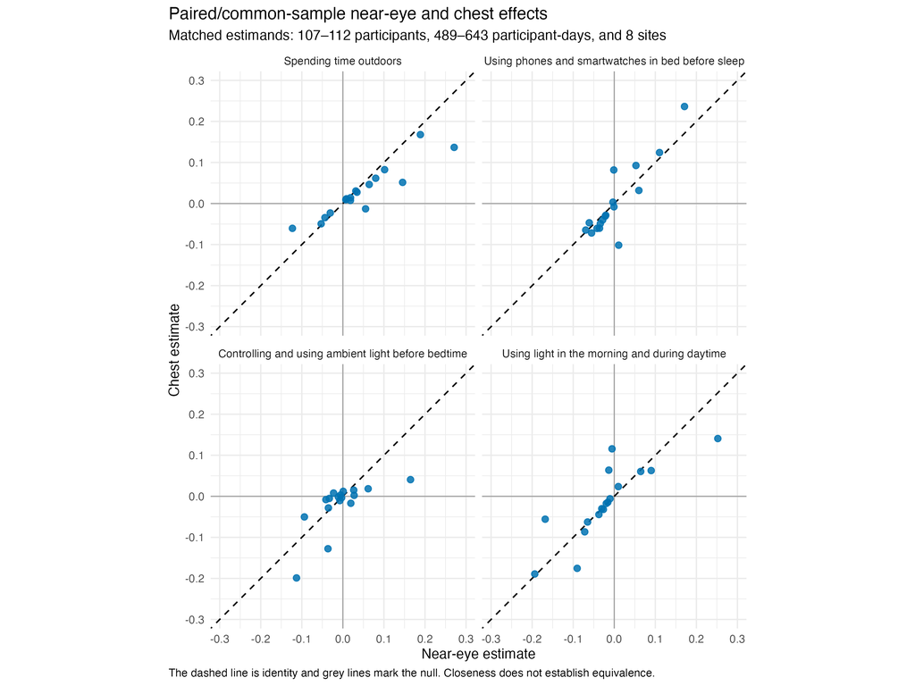

Exact common-sample model-scale effects with near eye on x and chest on y. The dashed 45-degree identity line describes concordance, grey lines mark the null, and equal x/y geometry is used. Samples contain 107–112 participants, 489–643 matched participant-days, and eight sites; IS and IV use 112 participant rows. Closeness to identity is not evidence of equivalence.

Exact plotted values, component confidence intervals, identifiers, and metric-specific matched samples are retained in the paired figure source data.

Paired/common placement estimates for the leading F2 cells

Component intervals are valid; the correlated difference interval is deferred

| Metric | Near-eye effect per SD (95% CI) | Chest effect per SD (95% CI) | Same direction | Stability |
| --- | --- | --- | --- | --- |
| Time above 1,000 lx melEDI | 1.208 × (1.058 to 1.378) | 1.183 × (1.029 to 1.359) | TRUE | direction_and_component_intervals_compatible |
| melEDI dose | 1.264 × (1.053 to 1.516) | 1.209 × (0.997 to 1.466) | TRUE | direction_and_component_intervals_compatible |

### All-available complementary chest family

The separate all-available chest family also has no BH-retained association. Its smallest BH-adjusted p is 0.224. F2 with time above 1,000 lx and corrected dose yields reader-scale ratios per SD of 1.190 and 1.232, respectively, but neither is multiplicity-retained.

### Gap-timing-unaware dataset

The identical implementation applied to the gap-timing-unaware dataset has no BH-retained result. This dataset still passed the general 50%-per-hour and 80%-per-day coverage rules, but the timing of remaining missing observations was not used for additional metric-specific adjustment. Its smallest BH-adjusted p is 0.070. Sixty-four of 68 primary-versus-alternative-preparation near-eye estimates preserve direction and have overlapping component intervals; four reverse direction, all among weak effects. The two leading F2 estimates are concordant and have overlapping intervals. This shows that their positive directions are not created by the primary preparation rules, but the complete multiplicity result remains null in both scenarios.

### Exactly identified longest-bout sensitivity

The mandatory exact-identifiability sensitivity retains 500 participant-days, 132 participants, and all nine sites. All four factor directions agree with the all-available lower-bound analysis. For F2, the reader-scale ratio is attenuated from 1.117 to 1.046 (95% CI 0.930 to 1.175). This reinforces the decision not to promote the unadjusted all-available longest-bout association.

## Claim disposition

| V0 claim or artifact | Stage 2 evidence | Proposed disposition |
| --- | --- | --- |
| “Only two of 68 comparisons were significant” | Zero of 68 approved primary tests has BH-adjusted p at or below 0.050 | Withdraw and replace with a complete-family null result |
| Positive F2–dose association | Positive estimate and raw interval, but BH-adjusted p = 0.124; ordinary residual warning | Report only as a non-multiplicity-retained estimate if useful |
| Positive F2–time-above-1,000-lx association | Positive estimate and raw interval, but BH-adjusted p = 0.124; diagnostics and major stability checks pass | Report only as a non-multiplicity-retained estimate if useful |
| “Duration above 250 lx” for the highlighted threshold | The actual metric is time above 1,000 lx melEDI | Correct the metric name; do not substitute the distinct waking 250-lx metric |
| ρ² as explained variance | Rank correlation does not provide that interpretation | Remove |
| Site can be omitted | H01 and H05 random-site instability support fixed-site adjustment | Remove; retain site in the model |
| Chest duplicates the near-eye interpretation | Neither chest implementation has a retained result | Replace with placement-specific evidence |
| Habitual behaviour is broadly less informative than immediate context | H05 alone cannot rank causal or predictive importance | Do not make this claim from H05 |

The strongest defensible H05 conclusion is: **after fixed-site adjustment and one complete 68-test BH correction, this dataset provides no multiplicity-retained evidence that any of the four LEBA factors is associated with the 17 selected personal light-exposure metrics.** Positive F2 estimates for time above 1,000 lx and corrected melEDI dose are stable but exploratory after multiplicity correction.

## Deferred analyses and production-computation decision

Deferred or unnecessary Stage 2 computations

Production computation is a conditional gate between Stages 2 and 3, not Stage 3 itself

| Item | Status | Reason | Impact_on_current_gate |
| --- | --- | --- | --- |
| Paired placement-difference cluster interval | Deferred | Requires participant-cluster bootstrap or an additional approved joint model; independent-component approximation would be invalid | None on the primary 68-test result |
| Coverage Rules B/C and relaxed native-epoch scenarios | Deferred | Alternative prepared inputs are not present in the frozen H05 model-data package | Could refine robustness, but cannot create an undeclared primary screen |
| Former MDER profile-support and preselected device-day batteries | Superseded for current MDER | They were defined for a different estimand; the current mean-of-viable-ratios upper-tail and influence checks are complete | No full 17-metric rerun or additional production computation is required |
| Alternative response-family fits | Not repeated | H01's fixed candidate assessment already retained the current sleep and L10 families with limitations; a new family requires a major author gate | Sleep results remain explicitly limited and support no claim |
| L10 noon conversion | Not run | Explicitly excluded by the author after H01 resolution | None |
| Production bootstrap | Not proposed | Primary effects have declared model-based intervals; no computation-heavy interval is required for the confirmatory result | No production-computation gate is required; mandatory Stage 3 follows |

No bootstrap pilot was run because the approved primary estimands have model-based intervals and the confirmatory conclusion does not depend on a paired placement-difference interval. If the author requires that difference interval, a separate 50- or 100-successful-refit participant-cluster pilot, runtime estimate, and approval gate are required before production.

## Stage 2 approval and transition to Stage 3

The author approved items 1–5 and 7 on 2026-08-01:

1. the zero-of-68 primary result and withdrawal of the two V0 significance claims;
2. the fixed-site effect and V0/corrected-matrix displays;
3. the original adequacy review, subsequently tightened at the Stage 3 author gate by designating the four sleep models unfit for inference;
4. the interpretation that the two leading F2 estimates are stable but not multiplicity-retained;
5. the complementary chest, paired/common, random-site, leave-one-site-out, gap-timing-unaware dataset, and exact-bout sensitivity interpretations;
6. the claim-disposition table and strongest defensible conclusion.

The former item 6 is superseded. The listed expensive analyses remain deferred, and no production bootstrap or simulation is required for the approved H05 inference. Production computation is an unnumbered conditional gate between Stages 2 and 3; it is not Stage 3. H05 therefore proceeds to the mandatory standalone reader-facing Stage 3 report and will stop again for author approval before the scientific preparation/provenance description.

This transition is recorded centrally as `H05-001` in `audit/decisions/h05_stage2_gate_and_stage3_transition.md`. The wording repair does not change a model, estimate, interval, diagnostic, sensitivity result, or claim.

## Reproducibility checks

The independent clean-session test verifies the complete 544-cell artifact structure, three 68-test families, identical full/reduced frames, 204 stored inferential model bundles, and all sensitivity and display contracts. Its METRIC-011 checks additionally verify the eight approved source-cell changes, four rebuilt primary L10 frames, 16 updated L10 result cells, 22 frozen-result reconciliations, unchanged samples, zero gap L10 refits, zero non-L10 refits, and zero BH-retained associations in every family.

```
R_LIBS=renv/library/macos/R-4.6/aarch64-apple-darwin23 \
NATHEALTH_PROJECT_ROOT=<project-root> \
Rscript --vanilla tests/hypotheses/H05/test_h05_stage2.R
```

All H05 Stage 2 artifacts are inventoried with SHA-256 hashes under `artifacts/12_manifests/H05/`. No model or sensitivity was rerun for the workflow-numbering repair. Shared decisions and ledgers remain coordinator-owned.